# Notebook

```python
import importlib
from typing import Dict
import numpy as np
from IPython.core.display import Markdown
from matplotlib import pyplot as plt
from shared.definitions import TuningResult
from shared.ml_config_core import ModelTrainingResult
from shared import stats_utils
from shared.ml_config_runner import build_production_model_for_tuning_result
from src import data_loader
from shared import graph
from shared import utils
import seaborn as sns
import pandas as pd
```

```python
VERBOSE = True
```

```python
utils.pandas_config(pd)
utils.plt_config(plt)

sns.set_theme(style="darkgrid", palette="pastel")
plt.style.use("fivethirtyeight")
```

```python
# Use this to select the model to train, gennerally there are certain advantages and disadvantages between using different tuning targets:
# e.g. F1 provides better classification accuracy
# PR-AUC however is only slightly worse but has much smoother probabilities which is more
# useful when when selecting thresholds for grades
INCLUDE_MODELS = [
    "XGBoostF1Base",
    "XGBoostTuneF1",
    "XGBoostTuneF1DummyDropFICO",
    "XGBoostPRAUCBase",
    "XGBoostTunePRAUC",
]
```

# 2.1.1 Training and Testing the Default Risk Model

The dataset is pre-split into a 20% test sample and a 80% training sample (10% of which is used for tuning):

```python
transformed_data = data_loader.load_processed_dataset(
    sample_size=data_loader.SampleSize.Full, tuning_df=False
)
if VERBOSE:
    print(f"Total Samples Loaded {len(transformed_data)}")
```

```
Total Samples Loaded 1210204
```

```python
cv_results_all_models: Dict[str, ModelTrainingResult] = {}

for model_key in INCLUDE_MODELS:
    tuning_result = TuningResult.load_serialized_tuning_result(model_key)

    cv_results = build_production_model_for_tuning_result(
        tuning_result=tuning_result, df=transformed_data
    )
    cv_results_all_models[model_key] = cv_results

    ModelTrainingResult.serialize_model(cv_results, model_key)
```

```
Training: XGBoostTuneF1 with: {'model__scale_pos_weight': 3, 'model__n_estimators': 50, 'model__min_child_weight': 2, 'model__max_depth': 10, 'model__learning_rate': 0.05, 'model__gamma': 0.05}
XGBoostF1Base: 98.2 seconds
Training: XGBoostTuneF1 with: {'feat_trans_DropLowImportanceFeatures__option': 0, 'feat_trans_inst_income_ratio__option': 0, 'feat_trans_loan_purpose__option': 1, 'model__scale_pos_weight': 2, 'model__n_estimators': 200, 'model__min_child_weight': 2, 'model__max_depth': 4, 'model__learning_rate': 0.…
XGBoostTuneF1: 79.0 seconds
Training: XGBoostTuneF1 with: {'feat_trans_dummy_drop_FICO__option': 1, 'model__scale_pos_weight': 5, 'model__n_estimators': 100, 'model__min_child_weight': 2, 'model__max_depth': 5, 'model__learning_rate': 0.01, 'model__gamma': 0}
XGBoostTuneF1DummyDropFICO: 92.5 seconds
Training: XGBoostTuneF1 with: {'model__scale_pos_weight': 10, 'model__n_estimators': 150, 'model__min_child_weight': 2.5, 'model__max_depth': 12, 'model__learning_rate': 0.3, 'model__gamma': 0.3}
XGBoostPRAUCBase: 329.2 seconds
Training: XGBoostTunePRAUC with: {'feat_trans_DropLowImportanceFeatures__option': 0, 'feat_trans_inst_income_ratio__option': 0, 'feat_trans_loan_purpose__option': 1, 'model__scale_pos_weight': 2, 'model__n_estimators': 50, 'model__min_child_weight': 3, 'model__max_depth': 5, 'model__learning_rate': …
XGBoostTunePRAUC: 45.2 seconds
```

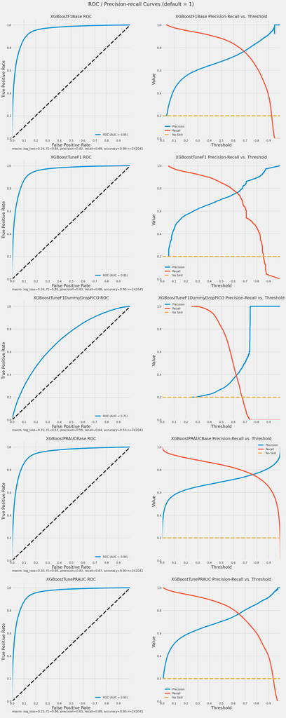

```python
importlib.reload(graph)
if len(cv_results_all_models) == 1:
    first_model = list(cv_results_all_models.keys())[0]
    cv_results_all_models[f"DUMMY_{first_model}"] = cv_results_all_models[first_model]
graph.roc_precision_recal_grid_plot(cv_results_all_models, add_fbeta_25=True)
```

The classification performance of all the models using the default 50% threshold is comparable (`XGBoostTuneF1DummyDropFICO` was included as a baseline).

We have chosen the `XGBoostTunePRAUC` configuration as our "production model" since it performs the best at predicting accurate probabilities (i.e. lowest log_loss).

`XGBoostPRAUCBase` (which achieves similar classification performance) uses a minimally processed dataset while `XGBoostTunePRAUC` uses several feature transformers (that were selected based on their impact on performances as part of our tuning process):

We have tried multiple other feature transformers (see `src/feature_engineering.py`) but they had negative or no signficant positive impact on performance.

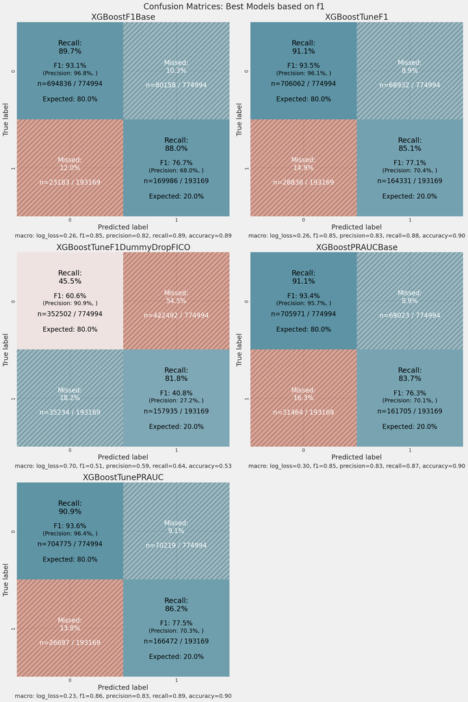

```python
importlib.reload(graph)

n = len(cv_results_all_models)
columns = 2
rows = (n + 1) // columns
height = 8
width = height * columns

fig, axes = plt.subplots(
    rows, columns, figsize=(width, height * rows), constrained_layout=True
)
plt.suptitle("Confusion Matrices: Best Models based on f1", fontsize=20)

axes_flat = axes.flatten()
for i, model_key in enumerate(cv_results_all_models.keys()):
    graph.confusion_matrix_plot_v2(
        cv_results_all_models[model_key].cm_data,
        title=model_key,
        annotations=graph.make_annotations(cv_results_all_models[model_key].cv_metrics),
        ax=axes_flat[i],
    )

# Hide any unused axes
for j in range(i + 1, len(axes_flat)):
    axes_flat[j].axis("off")

plt.show()
```

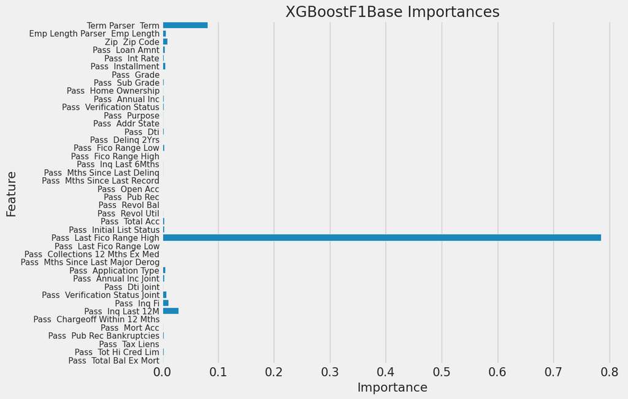

|  | Feature | Importance |
| --- | --- | --- |
| 0 | term_parser__term | 0.081260 |
| 1 | emp_length_parser__emp_length | 0.006472 |
| 2 | zip__zip_code | 0.009154 |
| 3 | pass__loan_amnt | 0.004362 |
| 4 | pass__int_rate | 0.002490 |
| 5 | pass__installment | 0.005185 |
| 6 | pass__grade | 0.001119 |
| 7 | pass__sub_grade | 0.002440 |
| 8 | pass__home_ownership | 0.001933 |
| 9 | pass__annual_inc | 0.002389 |
| 10 | pass__verification_status | 0.002797 |
| 11 | pass__purpose | 0.001496 |
| 12 | pass__addr_state | 0.001898 |
| 13 | pass__dti | 0.002965 |
| 14 | pass__delinq_2yrs | 0.000711 |
| 15 | pass__fico_range_low | 0.003922 |
| 16 | pass__fico_range_high | 0.000000 |
| 17 | pass__inq_last_6mths | 0.001345 |
| 18 | pass__mths_since_last_delinq | 0.001392 |
| 19 | pass__mths_since_last_record | 0.001066 |
| 20 | pass__open_acc | 0.001103 |
| 21 | pass__pub_rec | 0.000344 |
| 22 | pass__revol_bal | 0.001249 |
| 23 | pass__revol_util | 0.001627 |
| 24 | pass__total_acc | 0.003171 |
| 25 | pass__initial_list_status | 0.003253 |
| 26 | pass__last_fico_range_high | 0.784888 |
| 27 | pass__last_fico_range_low | 0.000000 |
| 28 | pass__collections_12_mths_ex_med | 0.000303 |
| 29 | pass__mths_since_last_major_derog | 0.000990 |
| 30 | pass__application_type | 0.005523 |
| 31 | pass__annual_inc_joint | 0.004056 |
| 32 | pass__dti_joint | 0.002053 |
| 33 | pass__verification_status_joint | 0.007221 |
| 34 | pass__inq_fi | 0.010771 |
| 35 | pass__inq_last_12m | 0.029097 |
| 36 | pass__chargeoff_within_12_mths | 0.000204 |
| 37 | pass__mort_acc | 0.002018 |
| 38 | pass__pub_rec_bankruptcies | 0.002296 |
| 39 | pass__tax_liens | 0.000652 |
| 40 | pass__tot_hi_cred_lim | 0.002852 |
| 41 | pass__total_bal_ex_mort | 0.001932 |

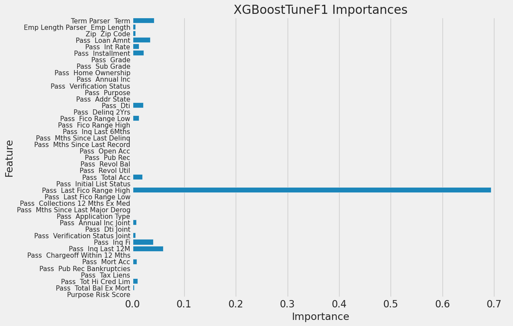

|  | Feature | Importance |
| --- | --- | --- |
| 0 | term_parser__term | 0.041694 |
| 1 | emp_length_parser__emp_length | 0.005625 |
| 2 | zip__zip_code | 0.005618 |
| 3 | pass__loan_amnt | 0.033847 |
| 4 | pass__int_rate | 0.012316 |
| 5 | pass__installment | 0.021628 |
| 6 | pass__grade | 0.000000 |
| 7 | pass__sub_grade | 0.000000 |
| 8 | pass__home_ownership | 0.000000 |
| 9 | pass__annual_inc | 0.000000 |
| 10 | pass__verification_status | 0.000000 |
| 11 | pass__purpose | 0.000000 |
| 12 | pass__addr_state | 0.000000 |
| 13 | pass__dti | 0.020426 |
| 14 | pass__delinq_2yrs | 0.000000 |
| 15 | pass__fico_range_low | 0.012295 |
| 16 | pass__fico_range_high | 0.000000 |
| 17 | pass__inq_last_6mths | 0.000000 |
| 18 | pass__mths_since_last_delinq | 0.000000 |
| 19 | pass__mths_since_last_record | 0.000000 |
| 20 | pass__open_acc | 0.000000 |
| 21 | pass__pub_rec | 0.000000 |
| 22 | pass__revol_bal | 0.000000 |
| 23 | pass__revol_util | 0.000000 |
| 24 | pass__total_acc | 0.019025 |
| 25 | pass__initial_list_status | 0.000000 |
| 26 | pass__last_fico_range_high | 0.693645 |
| 27 | pass__last_fico_range_low | 0.000000 |
| 28 | pass__collections_12_mths_ex_med | 0.000000 |
| 29 | pass__mths_since_last_major_derog | 0.000000 |
| 30 | pass__application_type | 0.000000 |
| 31 | pass__annual_inc_joint | 0.007208 |
| 32 | pass__dti_joint | 0.000000 |
| 33 | pass__verification_status_joint | 0.005732 |
| 34 | pass__inq_fi | 0.039876 |
| 35 | pass__inq_last_12m | 0.059146 |
| 36 | pass__chargeoff_within_12_mths | 0.000000 |
| 37 | pass__mort_acc | 0.008540 |
| 38 | pass__pub_rec_bankruptcies | 0.000000 |
| 39 | pass__tax_liens | 0.000000 |
| 40 | pass__tot_hi_cred_lim | 0.010032 |
| 41 | pass__total_bal_ex_mort | 0.003348 |
| 42 | purpose_risk_score | 0.000000 |

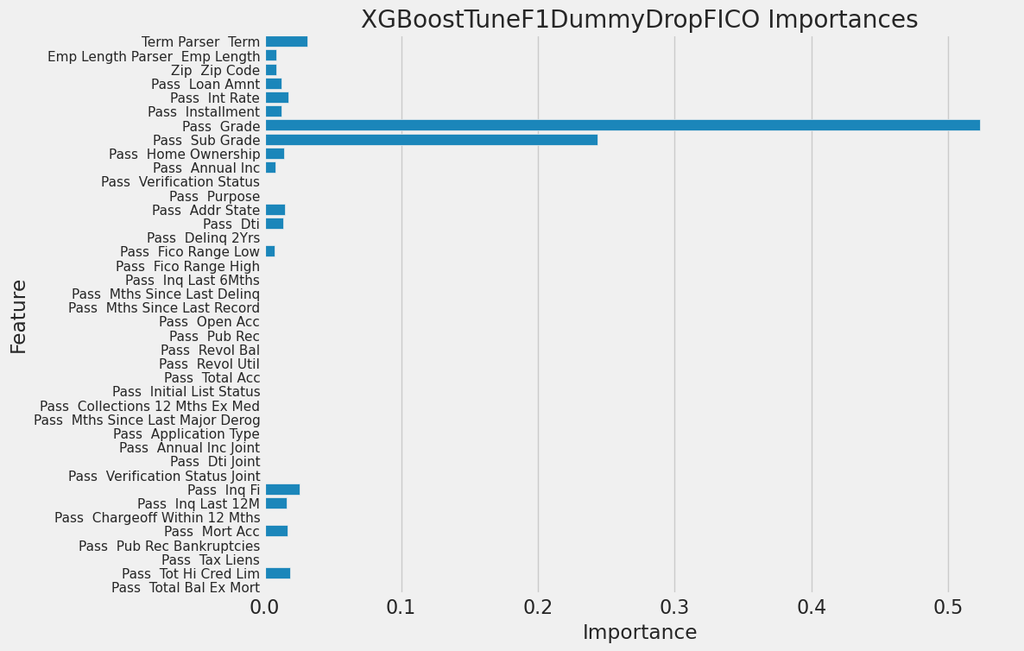

|  | Feature | Importance |
| --- | --- | --- |
| 0 | term_parser__term | 0.031716 |
| 1 | emp_length_parser__emp_length | 0.008676 |
| 2 | zip__zip_code | 0.008679 |
| 3 | pass__loan_amnt | 0.012592 |
| 4 | pass__int_rate | 0.017748 |
| 5 | pass__installment | 0.012326 |
| 6 | pass__grade | 0.523029 |
| 7 | pass__sub_grade | 0.243649 |
| 8 | pass__home_ownership | 0.014115 |
| 9 | pass__annual_inc | 0.008138 |
| 10 | pass__verification_status | 0.000457 |
| 11 | pass__purpose | 0.000627 |
| 12 | pass__addr_state | 0.014832 |
| 13 | pass__dti | 0.013609 |
| 14 | pass__delinq_2yrs | 0.000000 |
| 15 | pass__fico_range_low | 0.007460 |
| 16 | pass__fico_range_high | 0.000000 |
| 17 | pass__inq_last_6mths | 0.000566 |
| 18 | pass__mths_since_last_delinq | 0.000679 |
| 19 | pass__mths_since_last_record | 0.000000 |
| 20 | pass__open_acc | 0.000615 |
| 21 | pass__pub_rec | 0.000000 |
| 22 | pass__revol_bal | 0.000000 |
| 23 | pass__revol_util | 0.000379 |
| 24 | pass__total_acc | 0.000572 |
| 25 | pass__initial_list_status | 0.000000 |
| 26 | pass__collections_12_mths_ex_med | 0.000000 |
| 27 | pass__mths_since_last_major_derog | 0.000166 |
| 28 | pass__application_type | 0.000000 |
| 29 | pass__annual_inc_joint | 0.000000 |
| 30 | pass__dti_joint | 0.000346 |
| 31 | pass__verification_status_joint | 0.000000 |
| 32 | pass__inq_fi | 0.025813 |
| 33 | pass__inq_last_12m | 0.016484 |
| 34 | pass__chargeoff_within_12_mths | 0.000000 |
| 35 | pass__mort_acc | 0.017178 |
| 36 | pass__pub_rec_bankruptcies | 0.000000 |
| 37 | pass__tax_liens | 0.000000 |
| 38 | pass__tot_hi_cred_lim | 0.018954 |
| 39 | pass__total_bal_ex_mort | 0.000596 |

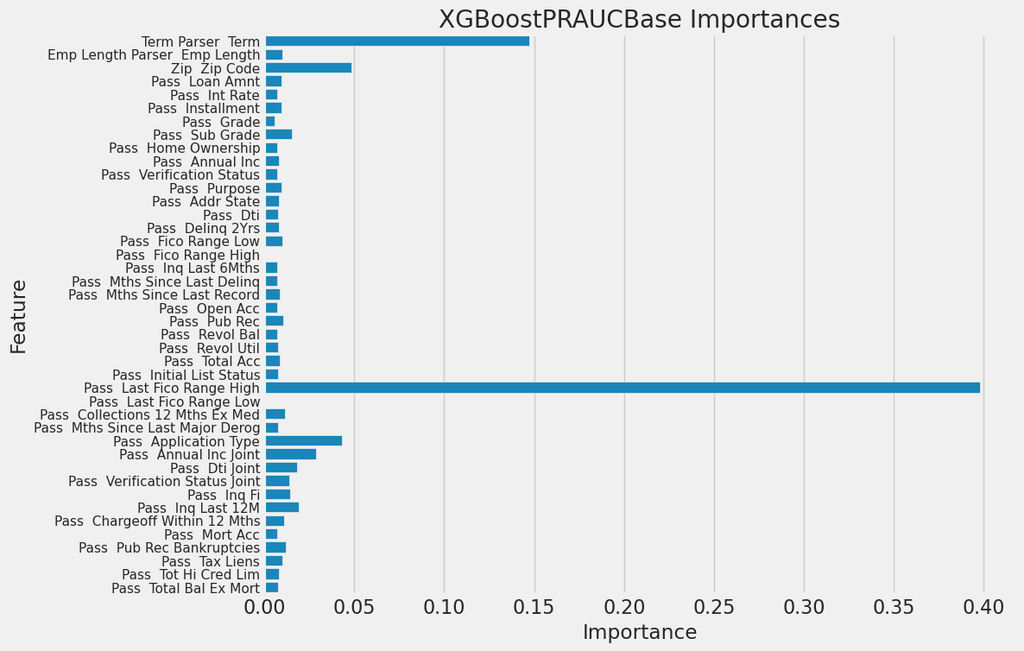

|  | Feature | Importance |
| --- | --- | --- |
| 0 | term_parser__term | 0.147525 |
| 1 | emp_length_parser__emp_length | 0.010144 |
| 2 | zip__zip_code | 0.048551 |
| 3 | pass__loan_amnt | 0.009661 |
| 4 | pass__int_rate | 0.007145 |
| 5 | pass__installment | 0.009508 |
| 6 | pass__grade | 0.005471 |
| 7 | pass__sub_grade | 0.015495 |
| 8 | pass__home_ownership | 0.007210 |
| 9 | pass__annual_inc | 0.008128 |
| 10 | pass__verification_status | 0.007234 |
| 11 | pass__purpose | 0.009398 |
| 12 | pass__addr_state | 0.008266 |
| 13 | pass__dti | 0.007766 |
| 14 | pass__delinq_2yrs | 0.007853 |
| 15 | pass__fico_range_low | 0.009847 |
| 16 | pass__fico_range_high | 0.000000 |
| 17 | pass__inq_last_6mths | 0.007134 |
| 18 | pass__mths_since_last_delinq | 0.007088 |
| 19 | pass__mths_since_last_record | 0.008396 |
| 20 | pass__open_acc | 0.006907 |
| 21 | pass__pub_rec | 0.010293 |
| 22 | pass__revol_bal | 0.006926 |
| 23 | pass__revol_util | 0.007376 |
| 24 | pass__total_acc | 0.008453 |
| 25 | pass__initial_list_status | 0.007738 |
| 26 | pass__last_fico_range_high | 0.397840 |
| 27 | pass__last_fico_range_low | 0.000000 |
| 28 | pass__collections_12_mths_ex_med | 0.011604 |
| 29 | pass__mths_since_last_major_derog | 0.007780 |
| 30 | pass__application_type | 0.043336 |
| 31 | pass__annual_inc_joint | 0.028541 |
| 32 | pass__dti_joint | 0.018120 |
| 33 | pass__verification_status_joint | 0.013861 |
| 34 | pass__inq_fi | 0.014235 |
| 35 | pass__inq_last_12m | 0.019005 |
| 36 | pass__chargeoff_within_12_mths | 0.011032 |
| 37 | pass__mort_acc | 0.007319 |
| 38 | pass__pub_rec_bankruptcies | 0.011996 |
| 39 | pass__tax_liens | 0.010005 |
| 40 | pass__tot_hi_cred_lim | 0.008131 |
| 41 | pass__total_bal_ex_mort | 0.007683 |

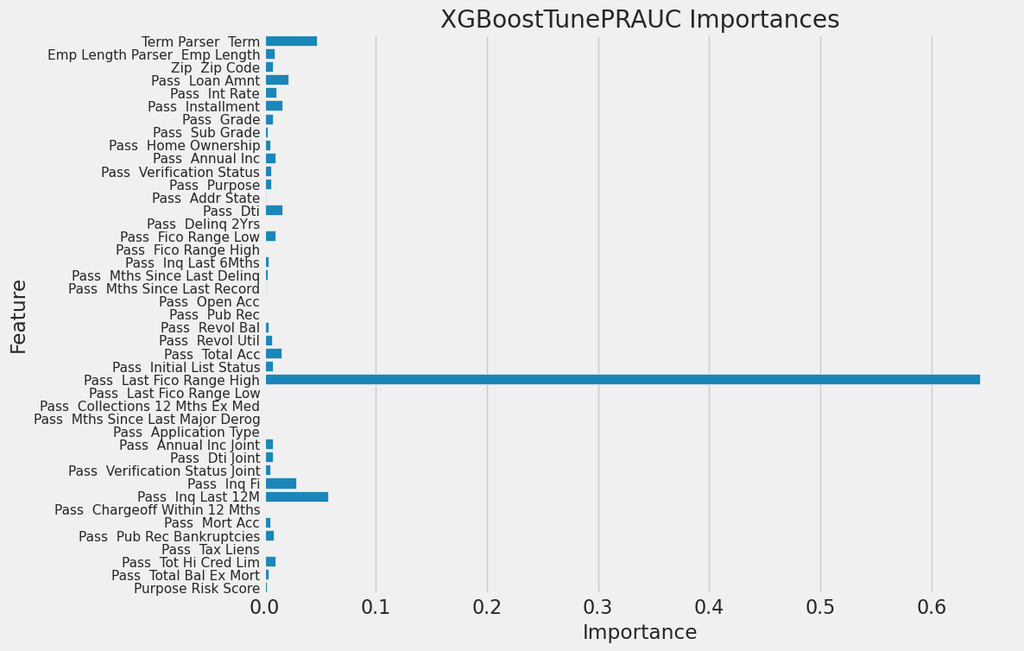

|  | Feature | Importance |
| --- | --- | --- |
| 0 | term_parser__term | 0.047196 |
| 1 | emp_length_parser__emp_length | 0.009523 |
| 2 | zip__zip_code | 0.007962 |
| 3 | pass__loan_amnt | 0.021693 |
| 4 | pass__int_rate | 0.011061 |
| 5 | pass__installment | 0.015877 |
| 6 | pass__grade | 0.007453 |
| 7 | pass__sub_grade | 0.002854 |
| 8 | pass__home_ownership | 0.005526 |
| 9 | pass__annual_inc | 0.010156 |
| 10 | pass__verification_status | 0.006244 |
| 11 | pass__purpose | 0.005823 |
| 12 | pass__addr_state | 0.001248 |
| 13 | pass__dti | 0.016517 |
| 14 | pass__delinq_2yrs | 0.000000 |
| 15 | pass__fico_range_low | 0.009993 |
| 16 | pass__fico_range_high | 0.000000 |
| 17 | pass__inq_last_6mths | 0.003550 |
| 18 | pass__mths_since_last_delinq | 0.002630 |
| 19 | pass__mths_since_last_record | 0.001133 |
| 20 | pass__open_acc | 0.000379 |
| 21 | pass__pub_rec | 0.000000 |
| 22 | pass__revol_bal | 0.003833 |
| 23 | pass__revol_util | 0.006724 |
| 24 | pass__total_acc | 0.015109 |
| 25 | pass__initial_list_status | 0.007440 |
| 26 | pass__last_fico_range_high | 0.643327 |
| 27 | pass__last_fico_range_low | 0.000000 |
| 28 | pass__collections_12_mths_ex_med | 0.000000 |
| 29 | pass__mths_since_last_major_derog | 0.000941 |
| 30 | pass__application_type | 0.000000 |
| 31 | pass__annual_inc_joint | 0.007815 |
| 32 | pass__dti_joint | 0.007615 |
| 33 | pass__verification_status_joint | 0.005253 |
| 34 | pass__inq_fi | 0.028570 |
| 35 | pass__inq_last_12m | 0.056947 |
| 36 | pass__chargeoff_within_12_mths | 0.000000 |
| 37 | pass__mort_acc | 0.005386 |
| 38 | pass__pub_rec_bankruptcies | 0.008609 |
| 39 | pass__tax_liens | 0.000000 |
| 40 | pass__tot_hi_cred_lim | 0.009844 |
| 41 | pass__total_bal_ex_mort | 0.003519 |
| 42 | purpose_risk_score | 0.002249 |

```python
importlib.reload(stats_utils)
for model_key in cv_results_all_models.keys():
    model_config = cv_results_all_models[model_key]
    feature_importances = stats_utils.get_model_feature_importances(
        model_config, transformed_data
    )

    graph.render_feature_importances_chart(
        feature_importances=feature_importances,
        title=f"{model_key} Importances",
    )
    if VERBOSE:
        display(feature_importances)
```

#### Analyzing and Predicting Grades

##### Average Default Rate by Grade in the Dataset:

```python
value_counts = transformed_data["pass__grade"].value_counts()
proportions = value_counts / value_counts.sum()

loan_status_ratio = transformed_data.groupby("pass__grade")[
    "target__loan_status"
].mean()
df = pd.DataFrame(
    {
        "Counts": value_counts,
        "Proportion": proportions,
        "Loan_Status_Ratio": loan_status_ratio,
    }
)

source_df_grades_summary = df.sort_index()
source_df_grades_summary
```

|  | Counts | Proportion | Loan_Status_Ratio |
| --- | --- | --- | --- |
| A | 211381 | 0.174666 | 0.060445 |
| B | 353495 | 0.292095 | 0.134030 |
| C | 343327 | 0.283693 | 0.224480 |
| D | 180840 | 0.149429 | 0.303639 |
| E | 84224 | 0.069595 | 0.384214 |
| F | 28719 | 0.023731 | 0.451165 |
| G | 8218 | 0.006791 | 0.501582 |

```python
sorted_grades = np.sort(transformed_data["pass__grade"].unique())
# Calculate the length of each section
num_grades = len(sorted_grades)
section_length = 1.0 / num_grades
palette = sns.color_palette("YlOrRd", n_colors=len(sorted_grades) - 1)

start_color = "grey"
end_color = "red"

colors = [start_color] + palette

log_scale = np.log(range(2, num_grades + 2))  # Change here, start range at 2
scale_factor = 1 / log_scale.sum()
cumulative_log_scale = np.cumsum(
    np.log(range(2, num_grades + 2))
)  # Cumulative sum of log values
normalized_log_scale = (
        cumulative_log_scale / cumulative_log_scale[-1]
)  # Normalize to max out at 1

sections = []
start = 0
for i, grade in enumerate(sorted_grades):
    if i == 0:
        start = 0
    else:
        start = normalized_log_scale[i - 1]
    end = normalized_log_scale[i]
    section = {
        "label": f"{grade} Grade",
        "start": start,
        "end": end,
        "color": colors[i],
        "description": "",  # Optional: Add descriptions as needed
    }
    sections.append(section)
if VERBOSE:
    sections
```

```python
cm_target_model_key = "XGBoostTunePRAUC"
cm_target_model = cv_results_all_models[cm_target_model_key]

target_cm_data = cm_target_model.test_data
```

### Evaluating Financial Returns/Performance

We'll use the model we have built to narrow down the sample of loans that have a lower risk to default.

This would be more useful to potential investors rather than the Lenders Club itself, they can use it in addition to the grade and other data provided by the Lenders Club to select the loans which not to invest it in.

```python
def calculate_loan_portfolio_metrics(data):
    """
    Calculate loan metrics including total loan amount, total interest paid, total return percentage, and total loss.

    Args:
    - data: DataFrame with columns 'target__loan_status', 'pass__loan_amnt', and 'pass__int_rate'

    Returns:
    - DataFrame: A DataFrame containing the calculated metrics.
    """
    data = data.copy()
    total_loan_amount = data["pass__loan_amnt"].sum()

    # Total Loss - Sum of loan amounts for loans that defaulted
    total_loss = data.loc[data["target__loan_status"] == 1, "pass__loan_amnt"].sum()

    # Total Interest Paid - Only from loans that did not default
    data["interest_paid"] = data.apply(
        lambda x: (x["pass__loan_amnt"] * x["pass__int_rate"] / 100)
        if x["target__loan_status"] == 0
        else 0,
        axis=1,
    )
    total_interest_paid = data["interest_paid"].sum()

    data["expected_interest"] = data["pass__loan_amnt"] * data["pass__int_rate"] / 100
    expected_total_interest = data["expected_interest"].sum()

    total_return_percent = (total_interest_paid / total_loan_amount) * 100

    expected_return_percent = (expected_total_interest / total_loan_amount) * 100

    metrics_df = pd.DataFrame(
        {
            "Total Loan Amount": [stats_utils.format_amount(total_loan_amount)],
            "Total Interest Paid": [stats_utils.format_amount(total_interest_paid)],
            "Expected Return %": [f"{expected_return_percent:2f}"],
            "Total Return %": [f"{total_return_percent:2f}"],
            "Total Loss": [stats_utils.format_amount(total_loss)],
        }
    )

    return metrics_df
```

The table below shows the total returns of all the loans in the dataset. We have to note that this is highly simplified because it assumes that all the loans that were defaulted on had to be completely written off but realistically this is not really the case:

- all lenders are likely to make at least some payments before they default
- defaulted loans can still be sold to third part for a fraction of the owed amount In future version of our model we should take these factors into account.

```python
calculate_loan_portfolio_metrics(transformed_data)
```

|  | Total Loan Amount | Total Interest Paid | Expected Return % | Total Return % | Total Loss |
| --- | --- | --- | --- | --- | --- |
| 0 | 17451.88m | 1770.28m | 13.645651 | 10.143752 | 3757.82m |

```python
def estimate_financial_improvement(data, predictions):
    """
    Estimate financial improvement by comparing actual financial metrics to hypothetical
    scenarios where loans predicted to default were not issued. Values requiring conversion
    to millions are converted upfront.

    Args:
    - data: DataFrame with actual loan data, including 'target__loan_status', 'pass__loan_amnt', and 'pass__int_rate'.
    - predictions: Series or list containing model predictions corresponding to the data.

    Returns:
    - DataFrame: A DataFrame containing both actual and hypothetical financial metrics, with appropriate formatting.
    """
    data_with_predictions = data.copy()
    data_with_predictions["predictions"] = predictions

    total_loan_amount_actual = (
            data["pass__loan_amnt"].sum() / 1_000_000
    )  # Convert to millions
    total_interest_paid_actual = (
            data.apply(
                lambda x: (x["pass__loan_amnt"] * x["pass__int_rate"] / 100)
                if x["target__loan_status"] == 0
                else 0,
                axis=1,
            ).sum()
            / 1_000_000
    )
    total_loss_actual = (
            data.loc[data["target__loan_status"] == 1, "pass__loan_amnt"].sum() / 1_000_000
    )
    total_return_percent_actual = (
                                          total_interest_paid_actual * 1_000_000 / (
                                              total_loan_amount_actual * 1_000_000)
                                  ) * 100

    # Calculations for hypothetical when using the model scenario
    hypothetical_data = data_with_predictions[data_with_predictions["predictions"] == 0]
    total_loan_amount_hypo = hypothetical_data["pass__loan_amnt"].sum() / 1_000_000
    total_interest_paid_hypo = (
            hypothetical_data.apply(
                lambda x: x["pass__loan_amnt"] * x["pass__int_rate"] / 100, axis=1
            ).sum()
            / 1_000_000
    )  # Convert to millions
    total_loss_hypo = (
            hypothetical_data.loc[
                hypothetical_data["target__loan_status"] == 1, "pass__loan_amnt"
            ].sum()
            / 1_000_000
    )  # Convert to millions
    total_return_percent_hypo = (
                                        total_interest_paid_hypo * 1_000_000 / (total_loan_amount_hypo * 1_000_000)
                                ) * 100  # Recalculate to correct percentage if total_loan_amount_hypo > 0 else 0

    losses_avoided = total_loss_actual - total_loss_hypo
    interest_lost = total_interest_paid_hypo - total_interest_paid_actual
    total_applications_actual = len(data)
    total_applications_hypo = len(hypothetical_data)

    improvement_metrics = {
        "Total Loan Amount": [
            f"{total_loan_amount_actual:.4f}M",
            f"{total_loan_amount_hypo:.4f}M",
        ],
        "Total Interest Paid": [
            f"{total_interest_paid_actual:.4f}M",
            f"{total_interest_paid_hypo:.4f}M",
        ],
        "Total Return %": [
            f"{total_return_percent_actual:.2f}%",
            f"{total_return_percent_hypo:.2f}%",
        ],
        "Default Rate": [
            f"{data_with_predictions['target__loan_status'].mean():.2%}",
            f"{hypothetical_data['target__loan_status'].mean():.2%}",
        ],
        "Total Loss": [f"{total_loss_actual:.4f}M", f"{total_loss_hypo:.4f}M"],
        "Losses Avoided": [None, f"{losses_avoided:.4f}M"],
        "Interest Lost": [None, f"{interest_lost:.4f}M"],
        "Total Applications Accepted": [
            total_applications_actual,
            total_applications_hypo,
        ],
    }

    improvement_df = pd.DataFrame(
        improvement_metrics, index=["Actual", "Hypothetical"]
    ).T

    return improvement_df
```

We have selected only the loans which are unlikely to default using the default 50% threshold (note that the predicted probabilities don't directly indicate the likelihood of default):

```python
estimate_financial_improvement(transformed_data, cm_target_model.test_data.predictions)
```

|  | Actual | Hypothetical |
| --- | --- | --- |
| Total Loan Amount | 17451.8813M | 2590.8104M |
| Total Interest Paid | 1770.2756M | 330.8115M |
| Total Return % | 10.14% | 12.77% |
| Default Rate | 19.96% | 3.69% |
| Total Loss | 3757.8181M | 94.0324M |
| Losses Avoided | None | 3663.7857M |
| Interest Lost | None | -1439.4641M |
| Total Applications Accepted | 1210204 | 182757 |

Our model is fairly conservative and has rejected most of the loans offered by the Lenders Club (i.e. more than 80% are considered to be too risky). This would make it not very useful for the Lenders Club itself (however we might be able to improve this tuning the threshold). However, from the perspective of potential investors this is perfectly acceptable because they are likely to only invest into a small subset of available loans.

Using our model would allow investors to signficantly improve their returns by 3% or so, further improvements might be possible by improving the threshold (we'll look into this in the next section).

### Calculating Probability Thresholds

If we're using our binary classification model to assign grades to loans based on default probabilities we can't directly try to predict the grades from the source dataset.

Basically what we can do is to use the source dataset as a baseline and try to determine whether our model can outperform the method the Lending Club is using for determine grades, we'll try to maintain the same ratio of grades while trying to minimize the default risk for loans included in top grades (basically we want to make sure that's the spread of default risk between grades is maximized i.e. default risk for grade A is as close to 0% and for grade F as close to 100% as possible while also ensuring that the risk increased with continuously with grade)

```python
# We'll bin the predicted probabilities into grades which, the maintain as much consistency as possible with the grading scale used by Lenders Club we'll keep the proportion of loans in each grade the same.
target_cm_data_sorted = target_cm_data.probabilities.sort_values(by=1).reset_index(
    drop=True
)

# Calculate cumulative proportions for thresholds
source_df_grades_summary["Cumulative"] = source_df_grades_summary["Proportion"].cumsum()

sections = []

palette = sns.color_palette("YlOrRd", n_colors=len(sorted_grades) - 1)

start_color = "grey"
end_color = "red"

colors = [start_color] + palette

i = 0

for grade, row in source_df_grades_summary.iterrows():
    if grade == source_df_grades_summary.index[0]:
        start = 0.0
    else:
        start = target_cm_data_sorted[1].quantile(previous_cumulative)

    end = target_cm_data_sorted[1].quantile(row["Cumulative"])
    sections.append(
        {
            "label": f"{grade} Grade",
            "start": start,
            "end": end,
            # Assign colors and descriptions as needed
            "color": colors[i],
            "description": "",
        }
    )
    i = i + 1
    previous_cumulative = row["Cumulative"]

# Example output
# for section in sections:
#     print(section)
```

```python
# Assuming source_df_grades_summary and target_cm_data are already defined
# Sort probabilities for cumulative proportion mapping
target_cm_data_sorted = target_cm_data.probabilities.sort_values(by=1).reset_index(
    drop=True
)

source_df_grades_summary["Cumulative"] = source_df_grades_summary["Proportion"].cumsum()

sections = []

palette = sns.color_palette("YlOrRd", n_colors=len(source_df_grades_summary) - 4)

start_color = "grey"
colors = (
        [start_color] + palette + ["red"]
)  # Ensure "red" is used for the merged EFG section

i = 0
previous_cumulative = 0

efg_weights = source_df_grades_summary.loc["E":"G", "Counts"]
efg_risks = source_df_grades_summary.loc["E":"G", "Loan_Status_Ratio"]
weighted_avg_risk_efg = np.average(efg_risks, weights=efg_weights)

# Find thresholds in target_cm_data that match cumulative proportions
for grade, row in source_df_grades_summary.iterrows():
    if grade == source_df_grades_summary.index[0]:
        start = 0.0
    else:
        start = target_cm_data_sorted[1].quantile(previous_cumulative)

    end = target_cm_data_sorted[1].quantile(row["Cumulative"])

    #  merge grades E, F, G
    if grade == "E":
        continue
    elif grade == "F":
        continue
    elif grade == "G":
        label = "E-F-G Grade"
        color = "red"
    else:
        label = f"{grade} Grade"
        color = colors[i]

    if grade == "G":
        description = f"Expected D. R.: {weighted_avg_risk_efg:.1%}"
    else:
        description = f"Expected D. R.: {row['Loan_Status_Ratio']:.1%}"

    sections.append(
        {
            "label": label,
            "start": start,
            "end": end,
            "color": color,
            "description": description,
        }
    )
    if grade != "G":
        i += 1
    previous_cumulative = row["Cumulative"]
sections[-1]["end"] = 1.0
# sections
```

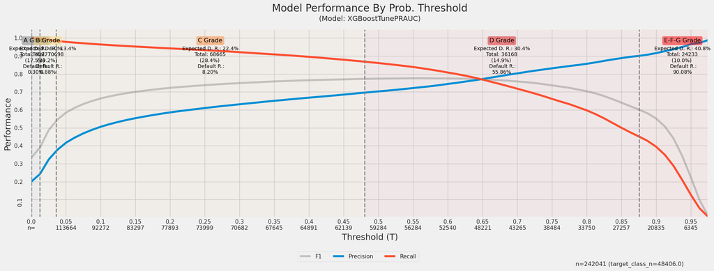

```python
importlib.reload(stats_utils)
importlib.reload(graph)
summary_desc = "`The chart shows the  performance of the if only individual with stroke Prob. > T are selected. Additionally the overlay indicates the number of people whose predicted P is in an given range. The overlays can be used to selected the most at risk individual based on the probability predicted for them`"

graph.plot_threshold_metrics_v2(
    target_cm_data,
    0,
    1,
    sections=sections,
    model_name=cm_target_model_key,
    class_pos=1,
    include_vars=["f1", "precision", "recall"],
    show_threshold_n=True,
    log_x=False,
)
display(Markdown(summary_desc))
```

We have used the predicted probabilities to suggest alternative grades for each loan. `Expected D.R` is the default rate based on original grades. We can see our grades are much better at excluding higher risk loans from higher grades.

Generally this does not necessarily mean that source grades are inaccurate or objectively worse, the investors club is likely using a more straightforward and transparent algorithm for assigning them and investors should be using additional criteria when selecting which loans to invest anyway.

#### Comparing Interest Rates for Predicted Grades

In this section we'll try to evaluate investment strategies that are entirely based on loan grades (either the original ones or ones provided by our model)

#### Predicted Grade Real Return Rates

```python
from src import utils as proj_utils

importlib.reload(proj_utils)
cm_target_model.test_data.x_test["pass__grade_merged"] = np.where(
    cm_target_model.test_data.x_test["pass__grade"].isin(["E", "F", "G"]),
    "E-F-G",
    cm_target_model.test_data.x_test["pass__grade"],
)

results = (
    cm_target_model.test_data.x_test.groupby("pass__grade_merged")
    .apply(proj_utils.calculate_metrics)
    .round(2)
)

display("Returns and Default Rate by Grade in Source Dataset:")
results
```

```
'Returns and Default Rate by Grade in Source Dataset:'
```

| pass__grade_merged | default_rate | mean_interest_rate | expected_return |
| --- | --- | --- | --- |
| A | 0.06 | 7.11 | 6.68 |
| B | 0.14 | 10.69 | 9.23 |
| C | 0.22 | 14.03 | 10.87 |
| D | 0.30 | 17.73 | 12.37 |
| E-F-G | 0.41 | 22.47 | 13.35 |

```python
def map_grade_prediction_based_on_prop_fact(sections):
    def map_grade_prediction_based_on_prop(row):
        for section in sections:
            if section["start"] <= row < section["end"]:
                return section["label"].replace(" Grade", "")
        return None  # Return None if no matching range is found

    return map_grade_prediction_based_on_prop


predicted_grades = cm_target_model.test_data.probabilities[1].map(
    map_grade_prediction_based_on_prop_fact(sections)
)
predictions_with_data = pd.concat(
    [
        cm_target_model.test_data.x_test,
        predicted_grades.to_frame(name="predicted_grades"),
    ],
    axis=1,
)
results = (
    predictions_with_data.groupby("predicted_grades")
    .apply(proj_utils.calculate_metrics)
    .round(3)
)

display("Returns and Default Rate Based on Default Probability Model:")
results
```

```
'Returns and Default Rate Based on Default Probability Model:'
```

| predicted_grades | default_rate | mean_interest_rate | expected_return |
| --- | --- | --- | --- |
| A | 0.003 | 10.357 | 10.326 |
| B | 0.009 | 12.271 | 12.164 |
| C | 0.082 | 13.943 | 12.800 |
| D | 0.559 | 14.714 | 6.495 |
| E-F-G | 0.901 | 16.862 | 1.672 |

We can see that while using our model to invested in the worst grades loans would lead to relatively poor returns investing in only in `C` grade or higher rated loans would provide better returns than using the Lenders Club's values to invest in the same loans:

- Investing only in `C` loans would provide almost the same returns as the far riskier `E-F-G` loans using the original grades.
- Only investing in `A` loans still yields ~10%, considering that the default rate is extremely low it might still be a preferable option to investing into high risk loans.

Basically using our model the investor would be able to minimize default risk while still getting decent returns i.e. if they only invested in loans with an estimated 10% default likelyhood or less using the original grades (so only `A` grade loans) they'd only make 6-7% while using our model this can be increased to more than 10%.

### Limitations

Therefore, to provide a more accurate estimate and to figure out whether our model would actually be useful we'd need to incorporate the actual amounts received etc.